# Experiment 1 Analysis

Joshua White

17 May, 2022

## Load Packages and set seed for reproducibility

```r
knitr::opts_chunk$set(echo = TRUE, cache = TRUE)
options(digits = 3)#sets inline code, and all code to only show 3 decimal places.

library(tidyverse)
library(here)
library(car)
library(ordinal)
library(MASS)
library(brms)
library(skimr)
library(jtools)
library(ggthemes)
library(ggpubr)
library(ggsci)

set.seed(1298)
```

## Import Data

```r
d <- read_csv("exp1data.csv", col_types = "ffffffnnfnfc")
glimpse(d)
```

```
## Rows: 1,207
## Columns: 12
## $ subject             <fct> o2lc35yzcpg, 7emt35yz8gy, go6e35yzl0i, pawc35yzk9o~
## $ condition           <fct> L7A, L11B, L4B, G10A, L12B, L1A, L11B, G5B, L6B, G~
## $ vignetteType        <fct> L, L, L, G, L, L, L, G, L, G, G, L, L, G, G, G, L,~
## $ vignetteNumber      <fct> 7, 11, 4, 10, 12, 1, 11, 5, 6, 8, 11, 8, 12, 1, 12~
## $ answerOrder         <fct> A, B, B, A, B, A, B, B, B, A, B, B, A, B, A, A, B,~
## $ vignette            <fct> L7, L11, L4, G10, L12, L1, L11, G5, L6, G8, G11, L~
## $ dummyVignetteAnswer <dbl> 7, 7, 7, 7, 7, 7, 7, 7, 7, 7, 7, 7, 7, 7, 6, 7, 7,~
## $ vignetteAnswer      <dbl> 2, 1, 6, 2, 4, 2, 4, 5, 6, 1, 6, 2, 4, 7, 6, 4, 4,~
## $ gender              <fct> male, female, male, female, female, male, female, ~
## $ age                 <dbl> 51, 35, 49, 24, 42, 75, 50, 35, 31, 42, 37, 41, 41~
## $ postQuestion1       <fct> correct, correct, correct, correct, correct, corre~
## $ postQuestion2       <chr> "I prefer to know the specific odds", NA, "I'd pre~
```

## Data Wrangling

#### Recode VignetteAnswer variable, create new variable, and reorder data

```r
d$vignetteAnswer[d$answerOrder == "A"] <- recode(d$vignetteAnswer[d$answerOrder == "A"], "1 = 3;
                                                                                          2 = 2;
                                                                                          3 = 1;
                                                                                          4 = 0;
                                                                                          5 = -1;
                                                                                          6 = -2;
                                                                                          7 = -3")

d$vignetteAnswer[d$answerOrder == "B"] <- recode(d$vignetteAnswer[d$answerOrder == "B"], "1 = -3;
                                                                                          2 = -2;
                                                                                          3 = -1;
                                                                                          4 = 0;
                                                                                          5 = 1;
                                                                                          6 = 2;
                                                                                          7 = 3")

#reset order of vignette factor from G1 to L12 for easy graphing
d$vignette <- factor(d$vignette, levels = c(sprintf("G%d", seq(1:12)), sprintf("L%d", seq(1:12))))


d
```

```
## # A tibble: 1,207 x 12
##    subject     condition vignetteType vignetteNumber answerOrder vignette
##    <fct>       <fct>     <fct>        <fct>          <fct>       <fct>
##  1 o2lc35yzcpg L7A       L            7              A           L7
##  2 7emt35yz8gy L11B      L            11             B           L11
##  3 go6e35yzl0i L4B       L            4              B           L4
##  4 pawc35yzk9o G10A      G            10             A           G10
##  5 rs7g35yz9py L12B      L            12             B           L12
##  6 7nql35yzygy L1A       L            1              A           L1
##  7 kx9135yz6xs L11B      L            11             B           L11
##  8 dp5j35yz3yf G5B       G            5              B           G5
##  9 21ls35yzp09 L6B       L            6              B           L6
## 10 in3g35yzivh G8A       G            8              A           G8
## # ... with 1,197 more rows, and 6 more variables: dummyVignetteAnswer <dbl>,
## #   vignetteAnswer <dbl>, gender <fct>, age <dbl>, postQuestion1 <fct>,
## #   postQuestion2 <chr>
```

## Instruction Checks

```r
# first remove andy's testing data point
andy.testing <- grep("amy", d$postQuestion2)
d_andyremoved <- d[-andy.testing,]

#check whether observations fail instruction checks
instr_fail <- d_andyremoved$postQuestion1 == "incorrect" | d_andyremoved$dummyVignetteAnswer <= 4

#remove data from main dataset and save for possible later analysis (was a particular question more confusing etc?)
d_removed <- d_andyremoved[instr_fail,]
d_pass <- d_andyremoved[!instr_fail,]

#inspect responses of those we removed.
d_removed
```

```
## # A tibble: 76 x 12
##    subject     condition vignetteType vignetteNumber answerOrder vignette
##    <fct>       <fct>     <fct>        <fct>          <fct>       <fct>
##  1 5fut35yz7wk L12A      L            12             A           L12
##  2 nqn635yza15 L9A       L            9              A           L9
##  3 eif335yzg4v G8A       G            8              A           G8
##  4 yfuw35yz7np G7A       G            7              A           G7
##  5 enz935yze1l L11A      L            11             A           L11
##  6 0yyy35yzo0v G10B      G            10             B           G10
##  7 2utk35yz3l9 L12B      L            12             B           L12
##  8 nha635yzuxd L11A      L            11             A           L11
##  9 bukf35yzagj G6A       G            6              A           G6
## 10 prhp35yz2ce G3B       G            3              B           G3
## # ... with 66 more rows, and 6 more variables: dummyVignetteAnswer <dbl>,
## #   vignetteAnswer <dbl>, gender <fct>, age <dbl>, postQuestion1 <fct>,
## #   postQuestion2 <chr>
```

## Quickly Inspect Final Data

```r
# inspect data before exclusions.
skim(d_andyremoved)
```

Data summary

| Name | d_andyremoved |
| --- | --- |
| Number of rows | 1206 |
| Number of columns | 12 |
| _______________________ |  |
| Column type frequency: |  |
| character | 1 |
| factor | 8 |
| numeric | 3 |
| ________________________ |  |
| Group variables | None |

**Variable type: character**

| skim_variable | n_missing | complete_rate | min | max | empty | n_unique | whitespace |
| --- | --- | --- | --- | --- | --- | --- | --- |
| postQuestion2 | 525 | 0.56 | 6 | 693 | 0 | 676 | 0 |

**Variable type: factor**

| skim_variable | n_missing | complete_rate | ordered | n_unique | top_counts |
| --- | --- | --- | --- | --- | --- |
| subject | 0 | 1 | FALSE | 1203 | bfb: 3, qc0: 2, o2l: 1, 7em: 1 |
| condition | 0 | 1 | FALSE | 48 | L11: 37, L5A: 35, L10: 33, G3A: 32 |
| vignetteType | 0 | 1 | FALSE | 2 | L: 619, G: 587 |
| vignetteNumber | 0 | 1 | FALSE | 12 | 11: 119, 8: 113, 3: 112, 5: 110 |
| answerOrder | 0 | 1 | FALSE | 2 | B: 609, A: 597 |
| vignette | 0 | 1 | FALSE | 24 | L11: 65, L2: 63, G3: 62, L5: 60 |
| gender | 0 | 1 | FALSE | 4 | fem: 605, mal: 597, oth: 3, na: 1 |
| postQuestion1 | 0 | 1 | FALSE | 2 | cor: 1190, inc: 16 |

**Variable type: numeric**

| skim_variable | n_missing | complete_rate | mean | sd | p0 | p25 | p50 | p75 | p100 | hist |
| --- | --- | --- | --- | --- | --- | --- | --- | --- | --- | --- |
| dummyVignetteAnswer | 0 | 1 | 6.65 | 1.17 | 1 | 7.00 | 7 | 7 | 7 | ▁▁▁▁▇ |
| vignetteAnswer | 0 | 1 | 0.53 | 1.58 | -3 | 0.00 | 0 | 2 | 3 | ▃▂▇▃▇ |
| age | 0 | 1 | 39.85 | 11.09 | 18 | 31.25 | 38 | 47 | 75 | ▃▇▅▂▁ |

```r
# inspect data after exclusions.
skim(d_pass)
```

Data summary

| Name | d_pass |
| --- | --- |
| Number of rows | 1130 |
| Number of columns | 12 |
| _______________________ |  |
| Column type frequency: |  |
| character | 1 |
| factor | 8 |
| numeric | 3 |
| ________________________ |  |
| Group variables | None |

**Variable type: character**

| skim_variable | n_missing | complete_rate | min | max | empty | n_unique | whitespace |
| --- | --- | --- | --- | --- | --- | --- | --- |
| postQuestion2 | 472 | 0.58 | 6 | 693 | 0 | 653 | 0 |

**Variable type: factor**

| skim_variable | n_missing | complete_rate | ordered | n_unique | top_counts |
| --- | --- | --- | --- | --- | --- |
| subject | 0 | 1 | FALSE | 1127 | bfb: 3, qc0: 2, o2l: 1, 7em: 1 |
| condition | 0 | 1 | FALSE | 48 | L11: 36, L5A: 34, L10: 33, L2B: 31 |
| vignetteType | 0 | 1 | FALSE | 2 | L: 584, G: 546 |
| vignetteNumber | 0 | 1 | FALSE | 12 | 5: 108, 11: 107, 3: 104, 6: 103 |
| answerOrder | 0 | 1 | FALSE | 2 | B: 581, A: 549 |
| vignette | 0 | 1 | FALSE | 24 | L2: 62, L5: 59, L11: 58, G3: 56 |
| gender | 0 | 1 | FALSE | 4 | fem: 578, mal: 549, oth: 2, na: 1 |
| postQuestion1 | 0 | 1 | FALSE | 1 | cor: 1130, inc: 0 |

**Variable type: numeric**

| skim_variable | n_missing | complete_rate | mean | sd | p0 | p25 | p50 | p75 | p100 | hist |
| --- | --- | --- | --- | --- | --- | --- | --- | --- | --- | --- |
| dummyVignetteAnswer | 0 | 1 | 6.92 | 0.32 | 5 | 7 | 7 | 7 | 7 | ▁▁▁▁▇ |
| vignetteAnswer | 0 | 1 | 0.53 | 1.59 | -3 | 0 | 0 | 2 | 3 | ▃▂▇▃▇ |
| age | 0 | 1 | 40.06 | 11.06 | 18 | 32 | 38 | 47 | 75 | ▃▇▅▂▁ |

```r
# how many people answered each vignette
d_pass %>% count(vignette) %>% arrange(n) %>% print(n = Inf)
```

```
## # A tibble: 24 x 2
##    vignette     n
##    <fct>    <int>
##  1 G12         33
##  2 G9          35
##  3 G2          39
##  4 L9          39
##  5 L1          40
##  6 G7          41
##  7 L4          41
##  8 L7          43
##  9 G4          44
## 10 G1          45
## 11 L12         45
## 12 L3          48
## 13 G5          49
## 14 G10         49
## 15 G11         49
## 16 L6          49
## 17 L10         49
## 18 L8          51
## 19 G8          52
## 20 G6          54
## 21 G3          56
## 22 L11         58
## 23 L5          59
## 24 L2          62
```

```r
# get an idea of the type of responses people gave for
d_pass$postQuestion2[!is.na(d_pass$postQuestion2)] %>% head(n = 50)
```

```
##  [1] "I prefer to know the specific odds"
##  [2] "I'd prefer to know the probability that each option would get discontinued. I was thinking 50/50 is better than not knowing the odds."
##  [3] "The possibility percentage was the same for each answer but there was something about seeing the actual percentage that made the choice more appealing."
##  [4] "With A it could be 50/50 as well so either one would have been an answer for me."
##  [5] "probably 50% situation rather than x%"
##  [6] "I would slightly prefer that the probabilities would be equal because if they weren't and I chose the 'wrong' one I feel like I would regret my choice more. With 50/50 it's a coin toss."
##  [7] "It seems like either could potentially be comparable (since B was unknown). It could also be more or less than A, so I chose the middle option."
##  [8] "I prefer situations where I know the exact statistics of the situation verses situations where the probabilities are unknown."
##  [9] "My reasoning was: With A, there's a 50% chance that it'll help, but then to me, that means there's a 50% chance that it won't. I'd therefore rather go with B that promises memory retention but with no guarantee of the percentage."
## [10] "It was a 50% shot either way"
## [11] "There wasn't any difference in choices in my opinion so I chose indifferent."
## [12] "I was thinking that is was best if I did not know which it was so that I would not worry about it."
## [13] "I was thinking that with that option, there would be a 50/50 chance, which I would like better than the unknown percentage chance of the other option."
## [14] "It seemed the logical choice to me"
## [15] "I chose that answer, because there was at least a 50% chance that person X the one that I was interested in is interested in me. I like those odds, its much better than 49% or zero chance! :)"
```

[output cut: 35 more lines]

## Graph responses

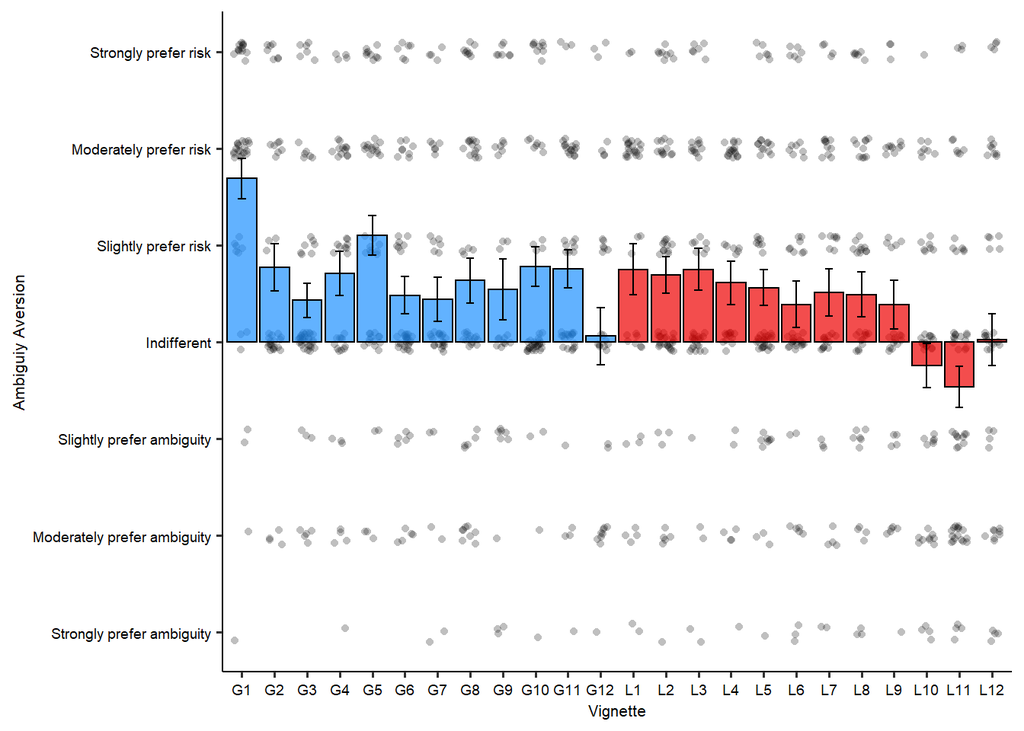

```r
# make plot
ggplot(d_pass, aes(x = vignette, y = vignetteAnswer, fill = vignetteType)) +
  geom_jitter(width = 0.25, height = 0.10, alpha = 0.25, show.legend = FALSE, shape = 16) +
  stat_summary(fun = mean, geom = "bar", alpha = 0.7, col = "black") +
  stat_summary(fun.data = mean_se, geom = "errorbar", width = 0.25, size = 0.5, linetype = 1, show.legend = FALSE) +
  scale_y_continuous(breaks = -3:3, minor_breaks = NULL, limits = (c(-3.10,3.10)),
                     labels = rev(c("Strongly prefer risk", "Moderately prefer risk", "Slightly prefer risk",
                                "Indifferent", "Slightly prefer ambiguity", "Moderately prefer ambiguity", "Strongly prefer ambiguity"))) +
  xlab("Vignette") +
  ylab("Ambiguiy Aversion") +
  scale_fill_manual(values = c("red2", "dodgerblue")) +
  theme_pubr() +
  theme(legend.position = "none",
        axis.text = element_text(size = 7),
        axis.title = element_text(size = 8))
```

```r
#ggsave("figures/exp1graph.png", height = 75, width = 150, units = "mm")
```

## Ambiguty aversion by demographics

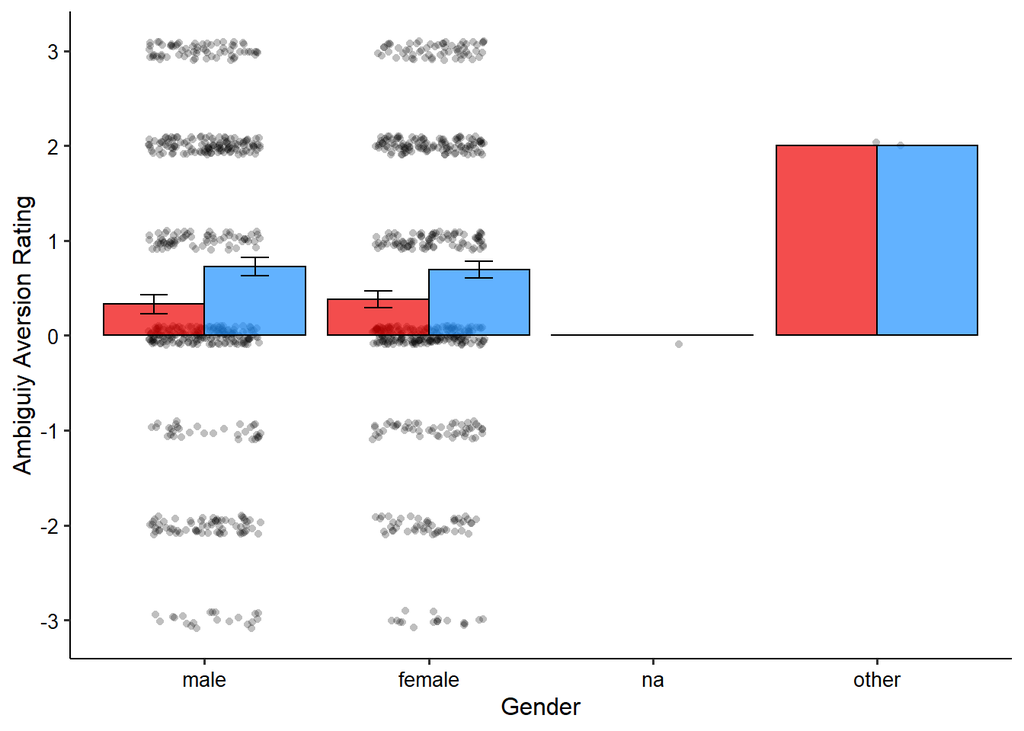

```r
## gender
ggplot(d_pass, aes(x = gender, y = vignetteAnswer, fill = vignetteType)) +
  geom_jitter(width = 0.25, height = 0.10, alpha = 0.25, show.legend = FALSE, shape = 16) +
  stat_summary(fun = mean, geom = "bar", alpha = 0.7, col = "black", position = "dodge") +
  stat_summary(fun.data = mean_se, geom = "errorbar", position = position_dodge(width = .9), width = 0.25, show.legend = FALSE) +
  scale_y_continuous(breaks = -3:3, minor_breaks = NULL, limits = (c(-3.10,3.10))) +
  xlab("Gender") +
  ylab("Ambiguiy Aversion Rating") +
  scale_fill_manual(values = c("red2", "dodgerblue")) +
  theme_pubr() +
  theme(legend.position = "none",
        axis.text = element_text(size = 10),
        axis.title = element_text(size = 12))
```

```r
t.test(d_pass$vignetteAnswer[d_pass$gender == "female"],
       d_pass$vignetteAnswer[d_pass$gender == "male"])
```

```
##
##  Welch Two Sample t-test
##
## data:  d_pass$vignetteAnswer[d_pass$gender == "female"] and d_pass$vignetteAnswer[d_pass$gender == "male"]
## t = 0.1257, df = 1105.4, p-value = 0.9
## alternative hypothesis: true difference in means is not equal to 0
## 95 percent confidence interval:
##  -0.1742185  0.1980681
## sample estimates:
## mean of x mean of y
## 0.5328720 0.5209472
```

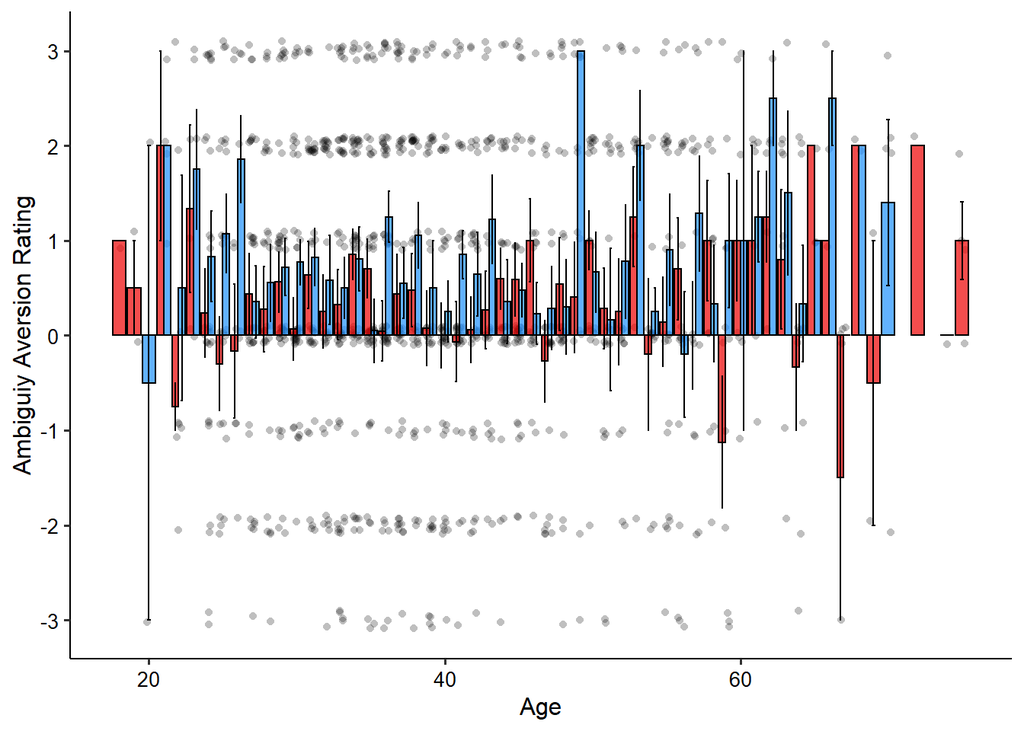

```r
# t test and graph shows no difference in gender

## age
ggplot(d_pass, aes(x = age, y = vignetteAnswer, fill = vignetteType)) +
  geom_jitter(width = 0.25, height = 0.10, alpha = 0.25, show.legend = FALSE, shape = 16) +
  stat_summary(fun = mean, geom = "bar", alpha = 0.7, col = "black", position = "dodge") +
  stat_summary(fun.data = mean_se, geom = "errorbar", position = position_dodge(width = .9), width = 0.25, show.legend = FALSE) +
  scale_y_continuous(breaks = -3:3, minor_breaks = NULL, limits = (c(-3.10,3.10))) +
  xlab("Age") +
  ylab("Ambiguiy Aversion Rating") +
  scale_fill_manual(values = c("red2", "dodgerblue")) +
  theme_pubr() +
  theme(legend.position = "none",
        axis.text = element_text(size = 10),
        axis.title = element_text(size = 12))
```

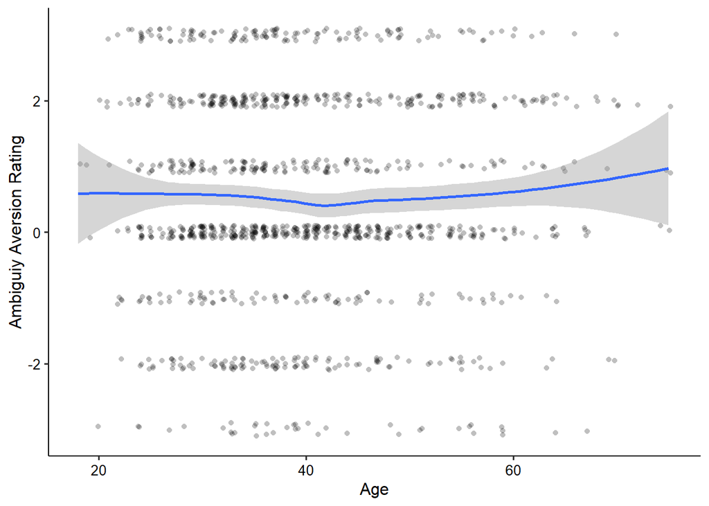

```r
ggplot(d_pass, aes(x = age, y = vignetteAnswer)) +
  geom_jitter(width = 0.25, height = 0.10, alpha = 0.25, show.legend = FALSE, shape = 16) +
  geom_smooth(method = "loess") +
  xlab("Age") +
  ylab("Ambiguiy Aversion Rating") +
  theme_pubr() +
  theme(legend.position = "none",
        axis.text = element_text(size = 10),
        axis.title = element_text(size = 12))
```

```r
summary(lm(vignetteAnswer ~ age, data = d_pass)) ## model shows no predictive effect of age
```

```
##
## Call:
## lm(formula = vignetteAnswer ~ age, data = d_pass)
##
## Residuals:
##     Min      1Q  Median      3Q     Max
## -3.5535 -0.5406 -0.5188  1.4672  2.4880
##
## Coefficients:
##              Estimate Std. Error t value Pr(>|t|)
## (Intercept) 0.4930775  0.1775440   2.777  0.00557 **
## age         0.0009018  0.0042723   0.211  0.83286
## ---
## Signif. codes:  0 '***' 0.001 '**' 0.01 '*' 0.05 '.' 0.1 ' ' 1
##
## Residual standard error: 1.588 on 1128 degrees of freedom
## Multiple R-squared:  3.95e-05,   Adjusted R-squared:  -0.000847
## F-statistic: 0.04456 on 1 and 1128 DF,  p-value: 0.8329
```

Ambiguity ratings do not differ as a function of gender or age.

## Data analysis: Fit ordinal logistic regression models

First, make vignetteAnswer an ordered factor

```r
d_pass$vignetteAnswer.ordfac <- ordered(d_pass$vignetteAnswer, levels = c("-3", "-2", "-1", "0", "1", "2", "3"))
```

### Frequentist

```r
olm.freq.nopred <-  clm(vignetteAnswer.ordfac ~ 1, data = d_pass, link = "logit")
olm.freq.GLpred <-  clm(vignetteAnswer.ordfac ~ vignetteType, data = d_pass, link = "logit")
olm.freq.ordpred <- clm(vignetteAnswer.ordfac ~ answerOrder, data = d_pass, link = "logit")
olmm.freq <-  clmm(vignetteAnswer.ordfac ~ vignetteType + (1|vignette), data = d_pass, link = "logit", nAGQ = 10) #values between 5 and 10 generally provide accurate maximum likelihood estimates -- documentation

summary(olm.freq.nopred)
```

```
## formula: vignetteAnswer.ordfac ~ 1
## data:    d_pass
##
##  link  threshold nobs logLik   AIC     niter max.grad cond.H
##  logit flexible  1130 -1980.88 3973.75 6(0)  3.91e-13 3.7e+01
##
## Threshold coefficients:
##       Estimate Std. Error z value
## -3|-2 -3.35818    0.16502 -20.350
## -2|-1 -1.86163    0.08719 -21.352
## -1|0  -1.33187    0.07318 -18.199
## 0|1    0.14183    0.05965   2.378
## 1|2    0.71580    0.06335  11.300
## 2|3    2.05772    0.09386  21.922
```

```r
summary(olm.freq.GLpred)
```

```
## formula: vignetteAnswer.ordfac ~ vignetteType
## data:    d_pass
##
##  link  threshold nobs logLik   AIC     niter max.grad cond.H
##  logit flexible  1130 -1975.09 3964.19 6(0)  4.10e-13 5.3e+01
##
## Coefficients:
##               Estimate Std. Error z value Pr(>|z|)
## vignetteTypeG   0.3605     0.1062   3.395 0.000687 ***
## ---
## Signif. codes:  0 '***' 0.001 '**' 0.01 '*' 0.05 '.' 0.1 ' ' 1
##
## Threshold coefficients:
##       Estimate Std. Error z value
## -3|-2 -3.19734    0.17130 -18.665
## -2|-1 -1.69554    0.09944 -17.051
## -1|0  -1.16220    0.08812 -13.189
## 0|1    0.31933    0.07961   4.011
## 1|2    0.89432    0.08285  10.794
## 2|3    2.24197    0.10921  20.528
```

```r
summary(olm.freq.ordpred)
```

```
## formula: vignetteAnswer.ordfac ~ answerOrder
## data:    d_pass
##
##  link  threshold nobs logLik   AIC     niter max.grad cond.H
##  logit flexible  1130 -1980.62 3975.24 6(0)  1.93e-13 5.7e+01
##
## Coefficients:
##              Estimate Std. Error z value Pr(>|z|)
## answerOrderB -0.07588    0.10582  -0.717    0.473
##
## Threshold coefficients:
##       Estimate Std. Error z value
## -3|-2 -3.39788    0.17417 -19.509
## -2|-1 -1.90128    0.10340 -18.388
## -1|0  -1.37140    0.09177 -14.945
## 0|1    0.10269    0.08082   1.271
## 1|2    0.67690    0.08332   8.124
## 2|3    2.01937    0.10790  18.716
```

```r
summary(olmm.freq)
```

```
## Cumulative Link Mixed Model fitted with the adaptive Gauss-Hermite
## quadrature approximation with 10 quadrature points
##
## formula: vignetteAnswer.ordfac ~ vignetteType + (1 | vignette)
## data:    d_pass
##
##  link  threshold nobs logLik   AIC     niter     max.grad cond.H
##  logit flexible  1130 -1963.78 3943.56 584(1755) 6.03e-03 1.4e+02
##
## Random effects:
##  Groups   Name        Variance Std.Dev.
##  vignette (Intercept) 0.1427   0.3778
## Number of groups:  vignette 24
##
## Coefficients:
##               Estimate Std. Error z value Pr(>|z|)
## vignetteTypeG   0.3655     0.1880   1.944   0.0519 .
## ---
## Signif. codes:  0 '***' 0.001 '**' 0.01 '*' 0.05 '.' 0.1 ' ' 1
##
## Threshold coefficients:
##       Estimate Std. Error z value
## -3|-2  -3.2701     0.2044 -16.002
## -2|-1  -1.7494     0.1489 -11.750
## -1|0   -1.2017     0.1413  -8.503
## 0|1     0.3276     0.1358   2.413
## 1|2     0.9229     0.1378   6.697
## 2|3     2.3032     0.1558  14.779
```

```r
coef(olm.freq.GLpred)
```

```
##         -3|-2         -2|-1          -1|0           0|1           1|2
##    -3.1973400    -1.6955444    -1.1622014     0.3193272     0.8943236
##           2|3 vignetteTypeG
##     2.2419670     0.3605211
```

```r
coef(olmm.freq)
```

```
##         -3|-2         -2|-1          -1|0           0|1           1|2
##    -3.2701033    -1.7493623    -1.2016721     0.3275622     0.9228813
##           2|3 vignetteTypeG
##     2.3032051     0.3655433
```

```r
exp1table.freq <- data.frame(Model = 1:4,
           Description = c("Intercept (i.e., cutpoints) only",
                          "Intercept (i.e., cutpoints) & Gain-or-Loss condition paramater",
                          "Intercept (i.e., cutpoints) & Gain-or-Loss condition paramater",
                          "Intercept (i.e., cutpoints), Gain-or-Loss condition, and random cutpoint parameters by vignette"),
           AIC = c(AIC(olm.freq.nopred), AIC(olm.freq.GLpred), AIC(olm.freq.ordpred), AIC(olmm.freq)))
library(papaja)
library(kableExtra)
apa_table(exp1table.freq, digits = 2,
          caption = 'Final parameter estimates for each model',
          note = 'v1')
```

(#tab:table)

*Final parameter estimates for each model*

| Model | Description | AIC |
| --- | --- | --- |
| 1 | Intercept (i.e., cutpoints) only | 3,973.75 |
| 2 | Intercept (i.e., cutpoints) & Gain-or-Loss condition paramater | 3,964.19 |
| 3 | Intercept (i.e., cutpoints) & Gain-or-Loss condition paramater | 3,975.24 |
| 4 | Intercept (i.e., cutpoints), Gain-or-Loss condition, and random cutpoint parameters by vignette | 3,943.56 |

*Note.* v1

```r
exp1table.freq
```

#### AIC values

The AIC values for our four different frequentist models are:

- 3973.75483 for the model with no predictors
- 3964.1884679 for the model with Gain or Loss as a predictor
- 3975.2405815 for the model with answer order as a predictor
- 3943.561792 for the mixed model with Gain or Loss and a random effect for vignette as predictors

### Bayesian

```r
olm.bayes.nopred <-  brm(vignetteAnswer.ordfac ~ 1, data = d_pass, family = cumulative(link = "logit"),
                         refresh = 0, open_progress = FALSE,
                         cores = 4, seed = 1298)  #to suppress progress printing to screen for .Rmd
olm.bayes.GLpred <-  brm(vignetteAnswer.ordfac ~ vignetteType, data = d_pass, family = cumulative(link = "logit"),
                         refresh = 0, open_progress = FALSE,
                         cores = 4, seed = 1298)
olm.bayes.ordpred <- brm(vignetteAnswer.ordfac ~ answerOrder, data = d_pass, family = cumulative(link = "logit"),
                         refresh = 0, open_progress = FALSE,
                         cores = 4, seed = 1298)
```

```
## recompiling to avoid crashing R session
```

```r
olmm.bayes <- brm(vignetteAnswer.ordfac ~ vignetteType + (1|vignette), data = d_pass, family = cumulative(link = "logit"),
                  refresh = 0, open_progress = FALSE,
                         cores = 4, seed = 1298)
prior_summary(olmm.bayes)
```

```
##                 prior     class          coef    group resp dpar nlpar bound
##                (flat)         b
##                (flat)         b vignetteTypeG
##  student_t(3, 0, 2.5) Intercept
##  student_t(3, 0, 2.5) Intercept             1
##  student_t(3, 0, 2.5) Intercept             2
##  student_t(3, 0, 2.5) Intercept             3
##  student_t(3, 0, 2.5) Intercept             4
##  student_t(3, 0, 2.5) Intercept             5
##  student_t(3, 0, 2.5) Intercept             6
##  student_t(3, 0, 2.5)        sd
##  student_t(3, 0, 2.5)        sd               vignette
##  student_t(3, 0, 2.5)        sd     Intercept vignette
##        source
##       default
##  (vectorized)
##       default
##  (vectorized)
##  (vectorized)
##  (vectorized)
##  (vectorized)
##  (vectorized)
##  (vectorized)
##       default
##  (vectorized)
##  (vectorized)
```

```r
summary(olm.bayes.nopred)
```

```
##  Family: cumulative
##   Links: mu = logit; disc = identity
## Formula: vignetteAnswer.ordfac ~ 1
##    Data: d_pass (Number of observations: 1130)
##   Draws: 4 chains, each with iter = 2000; warmup = 1000; thin = 1;
##          total post-warmup draws = 4000
##
## Population-Level Effects:
##              Estimate Est.Error l-95% CI u-95% CI Rhat Bulk_ESS Tail_ESS
## Intercept[1]    -3.37      0.17    -3.70    -3.06 1.00     2460     2007
## Intercept[2]    -1.86      0.09    -2.03    -1.70 1.00     4183     3647
## Intercept[3]    -1.33      0.07    -1.47    -1.19 1.00     4404     3551
## Intercept[4]     0.14      0.06     0.03     0.26 1.00     4171     3229
## Intercept[5]     0.72      0.06     0.60     0.84 1.00     4627     3155
## Intercept[6]     2.06      0.09     1.89     2.25 1.00     4714     3561
##
## Family Specific Parameters:
##      Estimate Est.Error l-95% CI u-95% CI Rhat Bulk_ESS Tail_ESS
## disc     1.00      0.00     1.00     1.00   NA       NA       NA
##
## Draws were sampled using sampling(NUTS). For each parameter, Bulk_ESS
## and Tail_ESS are effective sample size measures, and Rhat is the potential
## scale reduction factor on split chains (at convergence, Rhat = 1).
```

```r
summary(olm.bayes.GLpred)
```

```
##  Family: cumulative
##   Links: mu = logit; disc = identity
## Formula: vignetteAnswer.ordfac ~ vignetteType
##    Data: d_pass (Number of observations: 1130)
##   Draws: 4 chains, each with iter = 2000; warmup = 1000; thin = 1;
##          total post-warmup draws = 4000
##
## Population-Level Effects:
##               Estimate Est.Error l-95% CI u-95% CI Rhat Bulk_ESS Tail_ESS
## Intercept[1]     -3.21      0.17    -3.55    -2.89 1.00     2863     2660
## Intercept[2]     -1.70      0.10    -1.89    -1.51 1.00     4445     3192
## Intercept[3]     -1.16      0.09    -1.33    -0.99 1.00     4412     3039
## Intercept[4]      0.32      0.08     0.16     0.47 1.00     3867     3396
## Intercept[5]      0.90      0.08     0.74     1.06 1.00     4106     3616
## Intercept[6]      2.25      0.11     2.04     2.46 1.00     4162     3263
## vignetteTypeG     0.36      0.10     0.15     0.56 1.00     4237     2583
##
## Family Specific Parameters:
##      Estimate Est.Error l-95% CI u-95% CI Rhat Bulk_ESS Tail_ESS
## disc     1.00      0.00     1.00     1.00   NA       NA       NA
##
## Draws were sampled using sampling(NUTS). For each parameter, Bulk_ESS
## and Tail_ESS are effective sample size measures, and Rhat is the potential
## scale reduction factor on split chains (at convergence, Rhat = 1).
```

```r
summary(olm.bayes.ordpred)
```

```
##  Family: cumulative
##   Links: mu = logit; disc = identity
## Formula: vignetteAnswer.ordfac ~ answerOrder
##    Data: d_pass (Number of observations: 1130)
##   Draws: 4 chains, each with iter = 2000; warmup = 1000; thin = 1;
##          total post-warmup draws = 4000
##
## Population-Level Effects:
##              Estimate Est.Error l-95% CI u-95% CI Rhat Bulk_ESS Tail_ESS
## Intercept[1]    -3.40      0.18    -3.76    -3.06 1.00     2502     2383
## Intercept[2]    -1.90      0.10    -2.11    -1.70 1.00     4362     3101
## Intercept[3]    -1.37      0.09    -1.55    -1.19 1.00     4416     3438
## Intercept[4]     0.10      0.08    -0.06     0.26 1.00     4334     3290
## Intercept[5]     0.68      0.08     0.52     0.84 1.00     4516     3579
## Intercept[6]     2.02      0.11     1.81     2.24 1.00     5112     2827
## answerOrderB    -0.08      0.11    -0.29     0.14 1.00     5473     3004
##
## Family Specific Parameters:
##      Estimate Est.Error l-95% CI u-95% CI Rhat Bulk_ESS Tail_ESS
## disc     1.00      0.00     1.00     1.00   NA       NA       NA
##
## Draws were sampled using sampling(NUTS). For each parameter, Bulk_ESS
## and Tail_ESS are effective sample size measures, and Rhat is the potential
## scale reduction factor on split chains (at convergence, Rhat = 1).
```

```r
summary(olmm.bayes)
```

```
##  Family: cumulative
##   Links: mu = logit; disc = identity
## Formula: vignetteAnswer.ordfac ~ vignetteType + (1 | vignette)
##    Data: d_pass (Number of observations: 1130)
##   Draws: 4 chains, each with iter = 2000; warmup = 1000; thin = 1;
##          total post-warmup draws = 4000
##
## Group-Level Effects:
## ~vignette (Number of levels: 24)
##               Estimate Est.Error l-95% CI u-95% CI Rhat Bulk_ESS Tail_ESS
## sd(Intercept)     0.43      0.10     0.26     0.65 1.00     1460     2113
##
## Population-Level Effects:
##               Estimate Est.Error l-95% CI u-95% CI Rhat Bulk_ESS Tail_ESS
## Intercept[1]     -3.27      0.22    -3.71    -2.86 1.00     1672     2344
## Intercept[2]     -1.75      0.16    -2.07    -1.44 1.00     1585     1984
## Intercept[3]     -1.20      0.15    -1.51    -0.91 1.00     1571     2027
## Intercept[4]      0.33      0.15     0.04     0.63 1.00     1490     2342
## Intercept[5]      0.93      0.15     0.63     1.23 1.00     1551     2276
## Intercept[6]      2.32      0.17     2.00     2.65 1.00     1750     2611
## vignetteTypeG     0.37      0.21    -0.03     0.79 1.00     1284     1939
##
## Family Specific Parameters:
##      Estimate Est.Error l-95% CI u-95% CI Rhat Bulk_ESS Tail_ESS
## disc     1.00      0.00     1.00     1.00   NA       NA       NA
##
## Draws were sampled using sampling(NUTS). For each parameter, Bulk_ESS
## and Tail_ESS are effective sample size measures, and Rhat is the potential
## scale reduction factor on split chains (at convergence, Rhat = 1).
```

```r
## get LOOIC values

loo(olm.bayes.nopred)
```

```
##
## Computed from 4000 by 1130 log-likelihood matrix
##
##          Estimate   SE
## elpd_loo  -1986.8 19.8
## p_loo         5.9  0.2
## looic      3973.6 39.6
## ------
## Monte Carlo SE of elpd_loo is 0.0.
##
## All Pareto k estimates are good (k < 0.5).
## See help('pareto-k-diagnostic') for details.
```

```r
loo(olm.bayes.GLpred)
```

```
##
## Computed from 4000 by 1130 log-likelihood matrix
##
##          Estimate   SE
## elpd_loo  -1981.9 19.6
## p_loo         6.8  0.2
## looic      3963.9 39.1
## ------
## Monte Carlo SE of elpd_loo is 0.0.
##
## All Pareto k estimates are good (k < 0.5).
## See help('pareto-k-diagnostic') for details.
```

```r
loo(olm.bayes.ordpred)
```

```
##
## Computed from 4000 by 1130 log-likelihood matrix
##
##          Estimate   SE
## elpd_loo  -1987.6 19.8
## p_loo         7.0  0.2
## looic      3975.2 39.6
## ------
## Monte Carlo SE of elpd_loo is 0.0.
##
## All Pareto k estimates are good (k < 0.5).
## See help('pareto-k-diagnostic') for details.
```

```r
loo(olmm.bayes)
```

```
##
## Computed from 4000 by 1130 log-likelihood matrix
##
##          Estimate   SE
## elpd_loo  -1964.8 20.6
## p_loo        23.4  0.6
## looic      3929.6 41.2
## ------
## Monte Carlo SE of elpd_loo is 0.1.
##
## All Pareto k estimates are good (k < 0.5).
## See help('pareto-k-diagnostic') for details.
```

#### LOOIC values

The LOOIC values for our four different Bayesian models are (I was not able to easily extract the AIC from these models):

- 3973.5680228 for the model with no predictors
- 3963.8865767 for the model with Gain or Loss as a predictor
- 3975.2013103 for the model with answer order as a predictor
- 3929.5552263 for the mixed model with Gain or Loss and a random effect for vignette as predictors

## Urn Analysis

### Plot

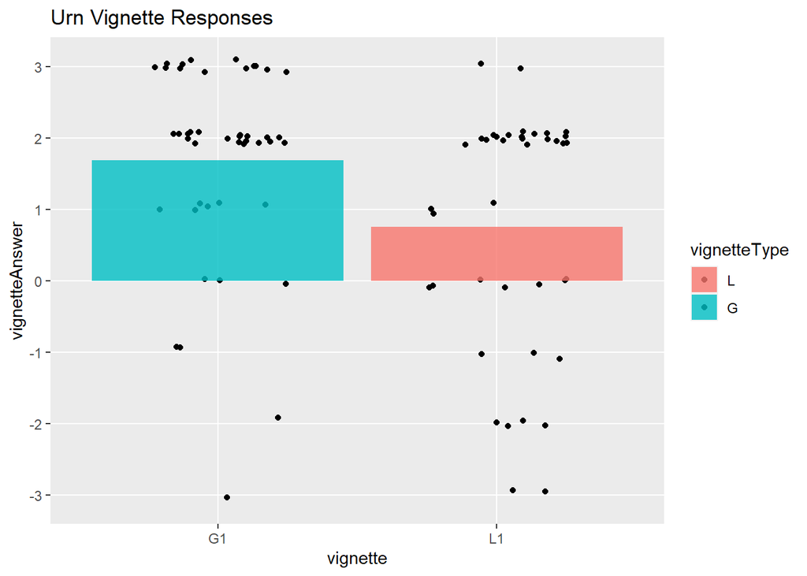

```r
##filter dataset to contain only urn vignettes
d_pass_urns <- d_pass %>% filter(vignette == "G1" | vignette == "L1")

##plot
ggplot(d_pass_urns, aes(x = vignette, y = vignetteAnswer, fill = vignetteType)) +
  geom_jitter(width = 0.25, height = 0.10) +
  stat_summary(fun.y=mean, geom="bar", alpha = 0.8) +
  scale_y_continuous(breaks = -3:3, minor_breaks = NULL, limits = (c(-3.10,3.10))) +
  ggtitle("Urn Vignette Responses")
```

### Statistical analyses

#### Frequentist

```r
olm.freq.nopred.urns <-  clm(vignetteAnswer.ordfac ~ 1, data = d_pass_urns, link = "logit")
olm.freq.GLpred.urns <-  clm(vignetteAnswer.ordfac ~ vignetteType, data = d_pass_urns, link = "logit")

summary(olm.freq.nopred.urns)
```

```
## formula: vignetteAnswer.ordfac ~ 1
## data:    d_pass_urns
##
##  link  threshold nobs logLik  AIC    niter max.grad cond.H
##  logit flexible  85   -136.59 285.17 5(0)  5.80e-08 4.6e+01
##
## Threshold coefficients:
##       Estimate Std. Error z value
## -3|-2  -3.3081     0.5878  -5.628
## -2|-1  -2.2644     0.3715  -6.096
## -1|0   -1.7117     0.3014  -5.680
## 0|1    -0.9916     0.2441  -4.062
## 1|2    -0.5046     0.2239  -2.254
## 2|3     1.5404     0.2845   5.414
```

```r
summary(olm.freq.GLpred.urns)
```

```
## formula: vignetteAnswer.ordfac ~ vignetteType
## data:    d_pass_urns
##
##  link  threshold nobs logLik  AIC    niter max.grad cond.H
##  logit flexible  85   -132.28 278.55 5(0)  4.27e-07 5.7e+01
##
## Coefficients:
##               Estimate Std. Error z value Pr(>|z|)
## vignetteTypeG   1.1962     0.4168    2.87  0.00411 **
## ---
## Signif. codes:  0 '***' 0.001 '**' 0.01 '*' 0.05 '.' 0.1 ' ' 1
##
## Threshold coefficients:
##       Estimate Std. Error z value
## -3|-2 -2.83913    0.60666  -4.680
## -2|-1 -1.77497    0.40388  -4.395
## -1|0  -1.20262    0.34450  -3.491
## 0|1   -0.44027    0.30661  -1.436
## 1|2    0.07463    0.29910   0.250
## 2|3    2.26067    0.39483   5.726
```

```r
AIC(olm.freq.nopred.urns)
```

```
## [1] 285.1705
```

```r
AIC(olm.freq.GLpred.urns)
```

```
## [1] 278.5517
```

#### AIC values

The AIC values for our two different frequentist models are:

- 285.1704832 for the model with no predictors
- 278.5516595 for the model with Gain or Loss as a predictor

These values illustrate that the existing effect is replicated in our findings. Firstly, ambiguity aversion exists in both gains and loss variants of the classic urn task. Secondly, the degree of ambiguity aversion is affected by whether we are discussing domains of loss or gain — ambiguity aversion is stronger for gains than for losses.

#### Bayesian

```r
olm.bayes.nopred.urns <- brm(vignetteAnswer.ordfac ~ 1, data = d_pass_urns, family = cumulative(link = "logit"),
                         refresh = 0, open_progress = FALSE, cores = 4,  seed = 1298)
olm.bayes.GLpred.urns <- brm(vignetteAnswer.ordfac ~ vignetteType, data = d_pass_urns, family = cumulative(link = "logit"),
                         refresh = 0, open_progress = FALSE, cores = 4,  seed = 1298)
summary(olm.bayes.nopred.urns)
```

```
##  Family: cumulative
##   Links: mu = logit; disc = identity
## Formula: vignetteAnswer.ordfac ~ 1
##    Data: d_pass_urns (Number of observations: 85)
##   Draws: 4 chains, each with iter = 2000; warmup = 1000; thin = 1;
##          total post-warmup draws = 4000
##
## Population-Level Effects:
##              Estimate Est.Error l-95% CI u-95% CI Rhat Bulk_ESS Tail_ESS
## Intercept[1]    -3.43      0.58    -4.67    -2.41 1.00     2127     1931
## Intercept[2]    -2.29      0.36    -3.03    -1.64 1.00     3849     3161
## Intercept[3]    -1.69      0.29    -2.27    -1.15 1.00     4564     3593
## Intercept[4]    -0.95      0.23    -1.41    -0.49 1.00     4560     3703
## Intercept[5]    -0.45      0.22    -0.87    -0.02 1.00     4366     3363
## Intercept[6]     1.59      0.28     1.05     2.17 1.00     4423     3058
##
## Family Specific Parameters:
##      Estimate Est.Error l-95% CI u-95% CI Rhat Bulk_ESS Tail_ESS
## disc     1.00      0.00     1.00     1.00   NA       NA       NA
##
## Draws were sampled using sampling(NUTS). For each parameter, Bulk_ESS
## and Tail_ESS are effective sample size measures, and Rhat is the potential
## scale reduction factor on split chains (at convergence, Rhat = 1).
```

```r
summary(olm.bayes.GLpred.urns)
```

```
##  Family: cumulative
##   Links: mu = logit; disc = identity
## Formula: vignetteAnswer.ordfac ~ vignetteType
##    Data: d_pass_urns (Number of observations: 85)
##   Draws: 4 chains, each with iter = 2000; warmup = 1000; thin = 1;
##          total post-warmup draws = 4000
##
## Population-Level Effects:
##               Estimate Est.Error l-95% CI u-95% CI Rhat Bulk_ESS Tail_ESS
## Intercept[1]     -2.98      0.61    -4.27    -1.90 1.00     2943     2573
## Intercept[2]     -1.81      0.40    -2.63    -1.07 1.00     4646     3217
## Intercept[3]     -1.18      0.34    -1.88    -0.55 1.00     5029     3275
## Intercept[4]     -0.40      0.31    -1.01     0.21 1.00     4786     3312
## Intercept[5]      0.14      0.30    -0.45     0.74 1.00     4586     3433
## Intercept[6]      2.31      0.39     1.59     3.10 1.00     4075     3276
## vignetteTypeG     1.20      0.41     0.43     2.01 1.00     4585     2780
##
## Family Specific Parameters:
##      Estimate Est.Error l-95% CI u-95% CI Rhat Bulk_ESS Tail_ESS
## disc     1.00      0.00     1.00     1.00   NA       NA       NA
##
## Draws were sampled using sampling(NUTS). For each parameter, Bulk_ESS
## and Tail_ESS are effective sample size measures, and Rhat is the potential
## scale reduction factor on split chains (at convergence, Rhat = 1).
```

```r
loo(olm.bayes.nopred.urns)
```

```
##
## Computed from 4000 by 85 log-likelihood matrix
##
##          Estimate   SE
## elpd_loo   -142.4  7.8
## p_loo         5.8  0.7
## looic       284.9 15.7
## ------
## Monte Carlo SE of elpd_loo is 0.0.
##
## All Pareto k estimates are good (k < 0.5).
## See help('pareto-k-diagnostic') for details.
```

```r
loo(olm.bayes.GLpred.urns)
```

```
##
## Computed from 4000 by 85 log-likelihood matrix
##
##          Estimate   SE
## elpd_loo   -139.2  8.0
## p_loo         6.8  0.8
## looic       278.3 16.0
## ------
## Monte Carlo SE of elpd_loo is 0.0.
##
## All Pareto k estimates are good (k < 0.5).
## See help('pareto-k-diagnostic') for details.
```

#### LOOIC values

- 284.855829 for the model with no predictors
- 278.3278794 for the model with Gain or Loss as a predictor

These values illustrate that the existing effect is replicated in our findings. Firstly, ambiguity aversion exists in both gains and loss variants of the classic urn task. Secondly, the degree of ambiguity aversion is affected by whether we are discussing domains of loss or gain — ambiguity aversion is stronger for gains than for losses.

#### Urn hypothesis tests

```r
## GAIN URN VIGNETTE ##

#ct test
rstatix::t_test(d_pass[d_pass$vignette == "G1", ], vignetteAnswer ~ 1, mu = 0)
```

```
## # A tibble: 1 x 7
##   .y.            group1 group2         n statistic    df        p
## * <chr>          <chr>  <chr>      <int>     <dbl> <dbl>    <dbl>
## 1 vignetteAnswer 1      null model    45      8.12    44 2.71e-10
```

```r
# wilcox test
rstatix::wilcox_test(d_pass[d_pass$vignette == "G1", ], vignetteAnswer ~ 1, mu = 0, exact = TRUE)
```

```
## # A tibble: 1 x 6
##   .y.            group1 group2         n statistic           p
## * <chr>          <chr>  <chr>      <int>     <dbl>       <dbl>
## 1 vignetteAnswer 1      null model    45       840 0.000000771
```

```r
rstatix::wilcox_effsize(d_pass[d_pass$vignette == "G1", ], vignetteAnswer ~ 1, mu = 0, exact = TRUE)
```

```
## # A tibble: 1 x 6
##   .y.            group1 group2     effsize     n magnitude
## * <chr>          <chr>  <chr>        <dbl> <int> <ord>
## 1 vignetteAnswer 1      null model   0.751    45 large
```

```r
## LOSS URN VIGNETTE ##

#ct test
rstatix::t_test(d_pass[d_pass$vignette == "L1", ], vignetteAnswer ~ 1, mu = 0)
```

```
## # A tibble: 1 x 7
##   .y.            group1 group2         n statistic    df      p
## * <chr>          <chr>  <chr>      <int>     <dbl> <dbl>  <dbl>
## 1 vignetteAnswer 1      null model    40      2.81    39 0.0078
```

```r
# wilcox test
rstatix::wilcox_test(d_pass[d_pass$vignette == "L1", ], vignetteAnswer ~ 1, mu = 0, exact = TRUE)
```

```
## # A tibble: 1 x 6
##   .y.            group1 group2         n statistic      p
## * <chr>          <chr>  <chr>      <int>     <dbl>  <dbl>
## 1 vignetteAnswer 1      null model    40      416. 0.0121
```

```r
rstatix::wilcox_effsize(d_pass[d_pass$vignette == "L1", ], vignetteAnswer ~ 1, mu = 0, exact = TRUE)
```

```
## # A tibble: 1 x 6
##   .y.            group1 group2     effsize     n magnitude
## * <chr>          <chr>  <chr>        <dbl> <int> <ord>
## 1 vignetteAnswer 1      null model   0.409    40 moderate
```

### Save data for use in experiment 2

```r
exp1d <- d_pass
save(exp1d, file = 'exp1d.rda')
```